# GECO Philippines SARS-CoV-2 Situation Report - 2023 MARCH

$~$

## Highlights

$~$

#### BA.2.3.20 sublineages continue to circulate in the country

## SARS-CoV-2 variants detected in the Philippines

$~$

| WHO label | Pango lineage | Classification | New submission | Isolated in 3 months | Total |
| --- | --- | --- | --- | --- | --- |
| Alpha | B.1.1.7/Q.x | VOC | 0 | 0 | 2807 |
| Beta | B.1.351 | VOC | 0 | 0 | 3282 |
| Delta | B.1.617.2/AY.x | VOC | 0 | 0 | 3500 |
| Gamma | P.1 | VOC | 0 | 0 | 3 |
| Omicron | B.1.1.529/BA.x | VOC | 120 (93) | 0 | 13683 |
| Eta | B.1.525 | VUM | 0 | 0 | 8 |
| Theta | P.3 | VUM | 0 | 0 | 529 |

**Table 1. Number of available sequences by variant in the Philippines as of 31 March 2023.** The variants (VOC/VUM) here only include sequences that present in the GISAID or GECO data base and fulfill the definitions of WHO at the time the report is prepared. *New submission*, new sequences submitted from the last report. *Isolated in 3 months*, sequences isolated from 1 December 2022 to 31 March 2023. Numbers in the parentheses are percentage of the category (%). Note that recombinant strains involving Omicron sublineages (e.g. XBB, XBC) are provisionally classified as “Omicron”.

$~$

- **VOC (Variant of Concern):** A SARS-CoV-2 variant that meets the definition of a VOI (see below) and, through a comparative assessment, has been demonstrated to be associated with (a) increase in transmissibility, (b) increase in clinical disease presentation or (c) decrease in effectiveness of public health measures including diagnostics, vaccines, therapeutics.
- **VOI (Variant of Interest):** A SARS-CoV-2 variant: (a) with genetic changes that are predicted or known to affect virus characteristics such as transmissibility, disease severity, immune escape, diagnostic or therapeutic escape; AND (b) identified to cause significant community transmission or multiple COVID-19 clusters, in multiple countries with increasing relative prevalence alongside increasing number of cases over time.
- **VUM (Variant Under monitoring):** A SARS-CoV-2 variant with genetic changes that are suspected to affect virus characteristics with some indication that it may pose a future risk, but evidence of phenotypic or epidemiological impact is currently unclear, requiring enhanced monitoring and repeat assessment pending new evidence.
- **Pango lineage:** A dynamic SARS-CoV-2 naming system that uses a phylogenetic framework (methods that involve a tree-like structure inferred based on genetic information of viruses) to identify actively spreading lineages. The Pango system is designed to track the transmission and spread of SARS-CoV-2, but does not attempt to identify or define VOCs or VOIs.

$~$

[interactive chart not shown]

- **Nextstrain clade** and the corresponding Pango lineage name: **21L** = BA.2, **22B** = BA.5, **22C** = BA.2.12.1, **22A** = BA.4, **22F** = XBB.

$~$

### Diversity within the Omicron variant

| Pango lineage | New submission | Isolated in 3 months | Total |
| --- | --- | --- | --- |
| BA.1.* | 0 | 0 | 598 |
| BA.2 | 4 (3.1) | 0 | 754 |
| BA.2.3 | 9 (7) | 0 | 5857 |
| BA.2.3.20.* | 62 (48.1) | 0 | 1176 |
| BA.2.12.1 | 0 | 0 | 119 |
| BA.2.75.* | 0 | 0 | 5 |
| Other BA.2.* | 0 | 0 | 153 |
| BA.4.* | 0 | 0 | 120 |
| BA.5 | 0 | 0 | 12 |
| BA.5.2.* | 0 | 0 | 3128 |

[output cut: 5 more lines]

**Table 1b. Number of available Omicron sequences in the Philippines as of 31 March 2023.** *New submission*, new sequences submitted from the last report. *Isolated in 3 months*, sequences isolated from 1 December 2022 to 31 March 2023. Numbers in the parentheses are percentage of the category (%). Phylogenetic relationship of the sublineages of Omicron variant is available [here](https://nextstrain.org/community/GECO-PH/GECO-covid@main/20230228?c=pango_lineage&d=tree,frequencies&f_country=Philippines&label=clade:21M%20%28Omicron%29&onlyPanels&p=full&sidebar=closed).

- **BA.2.3.20** includes its descending sulbineages CM. **BE.1** = BA.5.3.1.1, a sublineage of BA.5.3; **BQ.1** = BE.1.1.1.1, a sublineage of BE.1 (and also a sublineage of BA.5.3). **XBB** sublineages are recombinant viruses between BJ.1 (BA.2.10.1.1) and BA.2.75, whereas **XBC** are recombinant viruses between BA.2 and Delta.

$~$

### Diversity within the Delta variants

More than 70 Pango lineages have been found among Delta variants isolated in the Philippines, with >40 sublineages that have more than 2 isolated sequences as of March 2022. Phylogenetic relationship of the sublineages of Delta variant is available [here](https://nextstrain.org/community/GECO-PH/GECO-covid@main/20230228?c=pango_lineage&d=tree,frequencies&f_country=Philippines&label=clade:21A%20%28Delta%29&onlyPanels&p=full&sidebar=closed).

$~$ $~$

## SARS-CoV-2 variants detected by administrative region

$~$

| Region | New submission | Dominant variant in 3 months | Isolated in 3 months | Total |
| --- | --- | --- | --- | --- |
| NCR | 7 (5.4) | - | 1 (100) | 5814 |
| Ilocos | 4 (3.1) | - | 0 | 769 |
| CAR | 1 (0.8) | - | 0 | 1350 |
| Cagayan Valley | 0 | - | 0 | 1562 |
| Central Luzon | 1 (0.8) | - | 0 | 1687 |
| Calabarzon | 0 | - | 0 | 3518 |
| Mimaropa | 0 | - | 0 | 638 |
| Bicol | 0 | - | 0 | 738 |
| Western Visayas | 0 | - | 0 | 4445 |
| Central Visayas | 0 | - | 0 | 1194 |

[output cut: 7 more lines]

**Table 2. Number of available sequences by administrative region in the Philippines as of 31 March 2023.** *New submission*, new sequences submitted from the last report. *Dominant variant in 3 months*, the major variant isolated from 1 December 2022 to 31 March 2023. A dash indicates no sequence isolated. *Isolated in 3 months*, sequences isolated from 1 December 2022 to 31 March 2023. Numbers next to the dominant variant indicate percentage of the variant in the region, whereas other numbers in the parentheses are percentage of the category.

NCR, National Capital Region; CAR, Cordillera Administrative Region; BARMM, Bangsamoro Autonomous Region in Muslim Mindanao.

$~$

[interactive chart not shown]

**Figure 2. Frequencies of SARS-CoV-2 variants by administrative region in the Philippines since 1 December 2022.** The figure is constructed with a subsampled genomic data set from all available sequences as Figure 1. Frequencies of isolates in a particular time frame and frequencies classified with the Pango linage can be adjusted with the control panel (icon on top left/right).

- **Nextstrain clade** and the corresponding Pango lineage name: **22B** = BA.5, **22F** = XBB.

$~$ $~$

## Philippines specific SARS-CoV-2 lineages

$~$

[interactive chart not shown]

**Figure 3. Temporal frequencies of Philippine lineages (clusters) identified by [Grapevine-anywhere](https://github.com/GECO-PH/grapevine-anywhere).** Each sequence submitted to GECO database would undergo *Grapevine-anywhere* pipeline to detect sustain local transmission. A cluster is defined based on multiple sequences isolated in the Philippines that appeared to descend from the same introductory event on a phylogenetic tree. Phylogenetic relationships of these lineages can be found [here](https://nextstrain.org/community/GECO-PH/GECO-covid@main/20230228?c=cluster&d=tree&f_country=Philippines&onlyPanels&p=full&sidebar=closed).

$~$

| Cluster name | Date first identified | Pango lineage | Distribution | New submission | Isolated in 3 months | Total |
| --- | --- | --- | --- | --- | --- | --- |
| PH_37 | 2023-01-10 | XBB.1.2 | Davao; Caraga | 4 | 0 | 5 |
| PH_33 | 2022-11-22 | XBB.1 | Davao; Western Visayas | 3 | 0 | 6 |
| PH_43 | 2022-11-21 | XBB.1.2 | >3 regions | 1 | 0 | 9 |
| PH_35 | 2022-11-16 | XBB.1.2 | Western Visayas; Central Luzon | 0 | 0 | 5 |
| PH_61 | 2022-10-31 | XBB | Davao; Soccsksargen | 0 | 0 | 5 |
| PH_31 | 2022-10-24 | XBC.1 | Davao; Caraga; Soccsksargen | 7 | 0 | 49 |
| PH_69 | 2022-10-23 | XBB | Western Visayas; Davao | 1 | 0 | 22 |
| PH_56 | 2022-10-07 | XBB | Western Visayas; Calabarzon; NCR | 0 | 0 | 18 |
| PH_64 | 2022-10-05 | XBB | Western Visayas | 0 | 0 | 26 |
| PH_24 | 2022-10-04 | XBC.1 | Western Visayas | 0 | 0 | 7 |

[output cut: 242 more lines]

**Table 3. Number of sequences by cluster identified with the Grapevine-anywhere as of 31 March 2023.** A cluster is defined based on multiple sequences isolated in the Philippines that appeared to descend from the same introductory event on a phylogenetic tree. *Date first identified*, the isolation date of the first identified sequence. *Pango lineage*, the major Pango lineage of the sequences that belong to the same cluster. *New submission*, new sequences submitted from the last report. *Isolated in 3 months*, sequences isolated from 1 December 2022 to 31 March 2023.

$~$ $~$

## SARS-CoV-2 sequencing in the Philippines

$~$

### Total available SARS-CoV-2 sequences in the Philippines: **27679**

### SARS-CoV-2 sequences from GECO project: **3702**

$~$

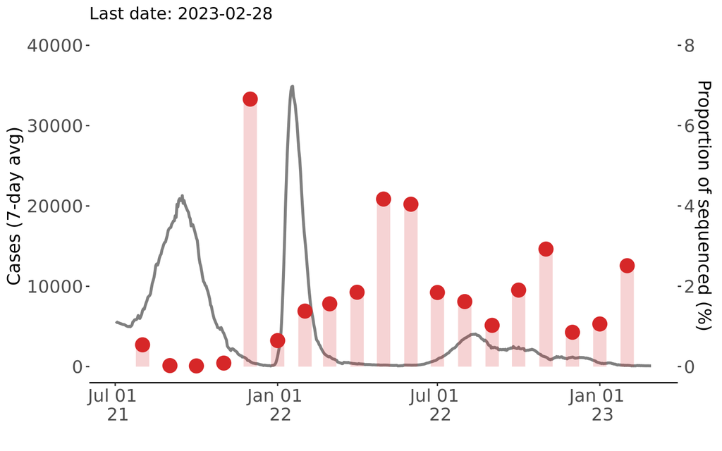

**Figure 4. Number of COVID-19 cases and the proportion of sequenced samples in the Philippines from July 2021.** The gray line indicates the mean cases in a 7 days window based on the JHU data base, whereas the red bars indicate the estimated percentage of sequenced samples among cases in a month.

$~$ $~$

## Epidemiology of COVID-19 in the Philippines

$~$

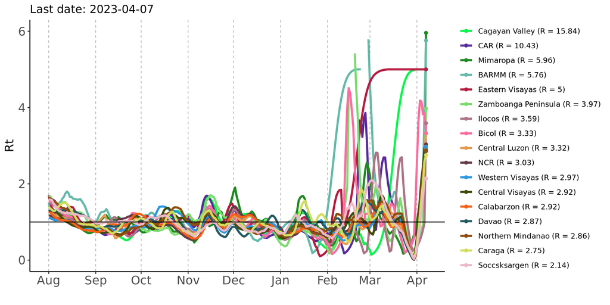

**Figure 5. Mean effective reproductive number (Rt) of COVID-19 in the Philippines by region from August 2022.** The reproductive number (R) is defined as the number of new infections that one infected patient can cause in a susceptible population. Here, *the mean effective reproductive number* (Rt) was inferred by daily number of cases reported in MOH, Philippines in a window of seven days. The horizontal line indicates one. If Rt is greater than 1, the case number in the region will likely continue to grow. If the Rt is below 1, the new cases may continue to appear at a slower rate. The R values denoted with the region name represent the most recent estimates. More regional epidemiological statistics can be found [here](https://github.com/GECO-PH/GECO-covid/blob/main/supp/region.md).

$~$ $~$

## SARS-CoV-2 mutations of interest

Omicron sublineage convergent sites

Other Spike protein

- **69-70Del** (Alpha, Omicron): [Distribution on the Philippine isolates](https://nextstrain.org/community/GECO-PH/GECO-covid@main/20230228?c=variant&d=tree&f_country=Philippines&gt=S.69-,70-&onlyPanels&p=full&sidebar=closed)
- **T95I** (Mu, Omicron): [Distribution on the Philippine isolates](https://nextstrain.org/community/GECO-PH/GECO-covid@main/20230228?c=gt-S_95&d=tree&f_country=Philippines&onlyPanels&p=full&sidebar=closed)
- **144-** (Alpha, Eta, Omicron): [Distribution on the Philippine isolates](https://nextstrain.org/community/GECO-PH/GECO-covid@main/20230228?c=gt-S_144&d=tree&f_country=Philippines&onlyPanels&p=full&sidebar=closed)
- **K417N** (Beta, Omicron): [Distribution on the Philippine isolates](https://nextstrain.org/community/GECO-PH/GECO-covid@main/20230228?c=gt-S_417&d=tree&f_country=Philippines&onlyPanels&p=full&sidebar=closed)
- **T478K** (Delta, Omicron): [Distribution on the Philippine isolates](https://nextstrain.org/community/GECO-PH/GECO-covid@main/20230228?c=gt-S_478&d=tree&f_country=Philippines&onlyPanels&p=full&sidebar=closed)
- **E484K** (Beta, Gamma, Eta, Mu): [Distribution on the Philippine isolates](https://nextstrain.org/community/GECO-PH/GECO-covid@main/20230228?c=gt-S_484&d=tree&f_country=Philippines&onlyPanels&p=full&sidebar=closed)
- **N501Y** (Alpha, Beta, Gamma, Mu, Omicron): [Distribution on the Philippine isolates](https://nextstrain.org/community/GECO-PH/GECO-covid@main/20230228?c=gt-S_501&d=tree&f_country=Philippines&onlyPanels&p=full&sidebar=closed)
- **H655Y** (Gamma, Omicron): [Distribution on the Philippine isolates](https://nextstrain.org/community/GECO-PH/GECO-covid@main/20230228?c=gt-S_655&d=tree&f_country=Philippines&onlyPanels&p=full&sidebar=closed)

$~$

Relevant functions including antibody escape (S 69-70Δ, S 144, S 346, S 417, S 484) and receptor binding (S 417, S 484, S 501). 69-70Del or 69-70Δ, deletions at positions 69-70.

$~$ $~$

## Data sources and references

Data

- [GECO website](https://www.geco-seqlab.org)
- [DOH Data drop](https://drive.google.com/drive/folders/1ZPPcVU4M7T-dtRyUceb0pMAd8ickYf8o)
- [GISAID](http://gisaid.org) (EPI-SET: EPI_SET_230228eg)
- [JHU COVID data](https://coronavirus.jhu.edu)

Methods

- [Analyses in this report](https://github.com/GECO-PH/GECO-covid/blob/main/supp/methods.md)
- [Nextstrain](https://nextstrain.org) ([build](https://nextstrain.org/community/GECO-PH/GECO-covid@main/20230228) for GECO project)
- [Grapevine-anywhere](https://github.com/GECO-PH/grapevine-anywhere)

References

- [WHO](https://www.who.int/en/activities/tracking-SARS-CoV-2-variants/)
- [Pango lineage list](https://cov-lineages.org/lineage_list.html)

### PDF version and previous reports

$~$

[figure not shown]